# Bike-Share Case Study

Omar Salah

2025-05-14

## Introduction

Cyclistic Bike-Share Case Study This case study was completed as part of the Google Data Analytics Capstone project. Cyclistic, a fictional bike-share company in Chicago, wants to maximize annual memberships. To help achieve this, we explore how casual riders and annual members differ in their usage behaviors and provide data-driven recommendations for the marketing team.

## Business Task

Our task is to analyze historical trip data to uncover usage patterns, compare behaviors between casual users and members, and recommend strategies to encourage membership sign-ups.

### Tools & Packages used for the Case Study

. R & RStudio

. tidyverse for data manipulation

. lubridate for date-time processing

. janitor for column cleaning . ggplot2 for data visualization

. R Markdown for reporting

### Data Source

For this project, I used only the data from Q1 of 2019 and 2020, as provided in the course materials. While using a more recent and comprehensive dataset would enhance the reliability and relevance of the analysis, I chose this limited scope intentionally. As this is my first data analytics project, working with a smaller dataset allowed me to focus on building foundational skills and completing a manageable end-to-end analysis process.

### 1. ASK PHASE

. How are the members and casual riders use the app differently . What days of the week and times are most popular for each?

### 2. PREPARE PHASE

. First I need to download the packages used for the analysis.

```r
library(tidyverse)
library(lubridate)
library(readr)
##### install.packages("janitor")
library(janitor)
##### install.packages("ggplot2")
library(ggplot2)
##### install.packages("dplyr")
library(dplyr)
```

. Now we have to load the data to Rstudio from our PC

```r
Q1_2019 <- Divvy_Trips_2019_Q1 <- read_csv("Divvy_Trips_2019_Q1.csv")
Q1_2020 <-  Divvy_Trips_2020_Q1 <- read_csv("Divvy_Trips_2020_Q1.csv")
```

### 3. PROCESS PHASE

. We can use (head & view) functions to view the data we loaded or (names & colnames) functions to view the coloums names

```r
colnames(Q1_2019)
```

```
##  [1] "trip_id"           "start_time"        "end_time"
##  [4] "bikeid"            "tripduration"      "from_station_id"
##  [7] "from_station_name" "to_station_id"     "to_station_name"
## [10] "usertype"          "gender"            "birthyear"
```

```r
 colnames(Q1_2020)
```

```
##  [1] "ride_id"            "rideable_type"      "started_at"
##  [4] "ended_at"           "start_station_name" "start_station_id"
##  [7] "end_station_name"   "end_station_id"     "start_lat"
## [10] "start_lng"          "end_lat"            "end_lng"
## [13] "member_casual"
```

. I found different coloum names have the same data between the two datasets, so I need to fix that before starting the analysis. . I am going to use the rename function to solve that problem

```r
q1_2020 <- Q1_2020 %>% rename(trip_id= "ride_id", start_time= "started_at", end_time= "ended_at", usertype= "member_casual")
q1_2019 <-  Q1_2019 %>% rename(start_station_id= "from_station_id", start_station_name= "from_station_name", end_station_id= "to_station_id", end_station_name= "to_station_name") %>%
   mutate(usertype= ifelse(usertype== "Subscriber", "member", "casual"))
```

. I couldn’t combine the datasets because some columns doesn’t have the same datatype so I’m changing that using the mutate function

```r
q1_2019 <- q1_2019 %>% mutate(trip_id= as.character(trip_id))
```

. After updating the names, I need to combine the two datasets to prepare for the cleaning process

```r
all_trips <- bind_rows(q1_2019,q1_2020)
```

```r
all_trips <- all_trips %>% mutate(start_time= ymd_hms(start_time),
                                  end_time= ymd_hms(end_time),
                                  tripduration= as.numeric(difftime(end_time, start_time, units = "mins")),
                                  tripduration_in_hrs= tripduration/60,
                                  day_of_week = wday(start_time, label = TRUE),
                                  month= month(start_time, label = TRUE),
                                  hour= hour(start_time))

all_trips_clean <- all_trips %>% clean_names()
```

. Remove negative or extreme ride length values

```r
all_trips_clean <- all_trips %>%
  filter(tripduration > 1, tripduration < 1440)
```

. Drop NA station names.

```r
all_trips_clean <- all_trips_clean %>%
  filter(!is.na(start_station_name), !is.na(end_station_name))
```

### 4. ANALYZE PHASE

. Now the data is ready for analysis.we can calculate the average results per rider type

```r
all_trips_clean %>%
  group_by(usertype) %>%
  summarise(average_ride= mean(tripduration,na.rm= TRUE),
            median_ride= median(tripduration, na.rm= TRUE),
            max_ride= max(tripduration, na.rm = TRUE))
```

```
## # A tibble: 2 × 4
##   usertype average_ride median_ride max_ride
##   <chr>           <dbl>       <dbl>    <dbl>
## 1 casual           38.5        23.2    1436.
## 2 member           11.5         8.5    1433.
```

. Number of rides per weekday

```r
all_trips_clean %>%
  group_by(usertype, day_of_week) %>%
  summarise(num_rides = n()) %>%
  arrange(usertype, day_of_week)
```

```
## # A tibble: 14 × 3
## # Groups:   usertype [2]
##    usertype day_of_week num_rides
##    <chr>    <ord>           <int>
##  1 casual   Sun             18512
##  2 casual   Mon              5558
##  3 casual   Tue              7266
##  4 casual   Wed              7623
##  5 casual   Thu              7085
##  6 casual   Fri              7954
##  7 casual   Sat             13399
##  8 member   Sun             59694
##  9 member   Mon            109852
## 10 member   Tue            127359
## 11 member   Wed            121296
## 12 member   Thu            124562
## 13 member   Fri            114586
## 14 member   Sat             59032
```

. Average duration length per weekday

```r
all_trips_clean %>%
  group_by(usertype, day_of_week) %>%
  summarise(avg_duration = mean(tripduration, na.rm = TRUE)) %>%
  arrange(usertype, day_of_week)
```

```
## # A tibble: 14 × 3
## # Groups:   usertype [2]
##    usertype day_of_week avg_duration
##    <chr>    <ord>              <dbl>
##  1 casual   Sun                 41.0
##  2 casual   Mon                 34.5
##  3 casual   Tue                 35.7
##  4 casual   Wed                 41.3
##  5 casual   Thu                 35.4
##  6 casual   Fri                 37.2
##  7 casual   Sat                 39.0
##  8 member   Sun                 13.0
##  9 member   Mon                 11.2
## 10 member   Tue                 11.4
## 11 member   Wed                 11.2
## 12 member   Thu                 11.1
## 13 member   Fri                 11.2
## 14 member   Sat                 12.5
```

. Rides per month

```r
all_trips_clean %>%
  group_by(usertype, month) %>%
  summarise(num_rides = n()) %>%
  arrange(month)
```

```
## # A tibble: 6 × 3
## # Groups:   usertype [2]
##   usertype month num_rides
##   <chr>    <ord>     <int>
## 1 casual   Jan       12269
## 2 member   Jan      233466
## 3 casual   Feb       14833
## 4 member   Feb      218905
## 5 casual   Mar       40295
## 6 member   Mar      264010
```

### 5. SHARE PHASE

. After the analysis, let’s visualize our findings using the ggplot package: First, number of rides by day of week.

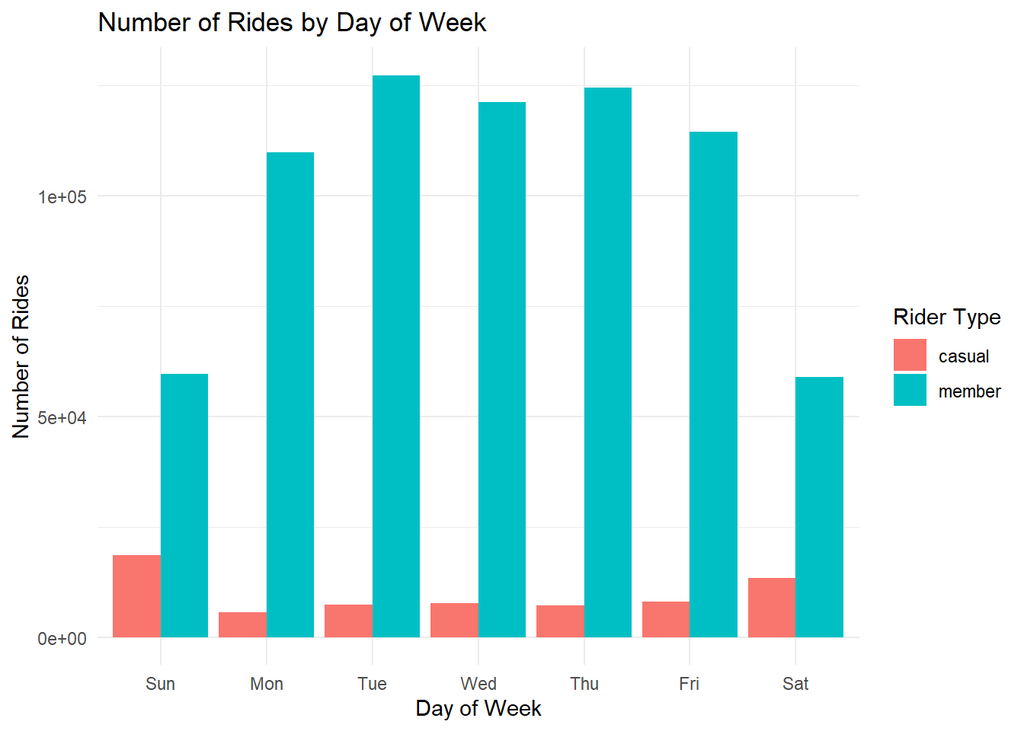

```r
all_trips_clean %>%
  group_by(usertype, day_of_week) %>%
  summarise(num_rides = n()) %>%
  ggplot(aes(x = day_of_week, y = num_rides, fill = usertype)) +
  geom_col(position = "dodge") +
  labs(title = "Number of Rides by Day of Week",
       x = "Day of Week",
       y = "Number of Rides",
       fill = "Rider Type") +
  theme_minimal()
```

. Second,Average trip duration per day.

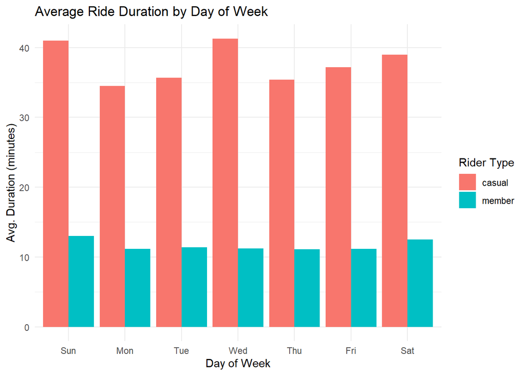

```r
all_trips_clean %>%
  group_by(usertype, day_of_week) %>%
  summarise(average_tripduration= mean(tripduration, na.rm= TRUE)) %>%
  ggplot(aes(x= day_of_week, y= average_tripduration, fill= usertype))+
  geom_col(position = "dodge")+
  labs(title = "Average Ride Duration by Day of Week",
       x = "Day of Week",
       y = "Avg. Duration (minutes)",
       fill = "Rider Type") +
  theme_minimal()
```

. Numbers of rides per month per usertype.

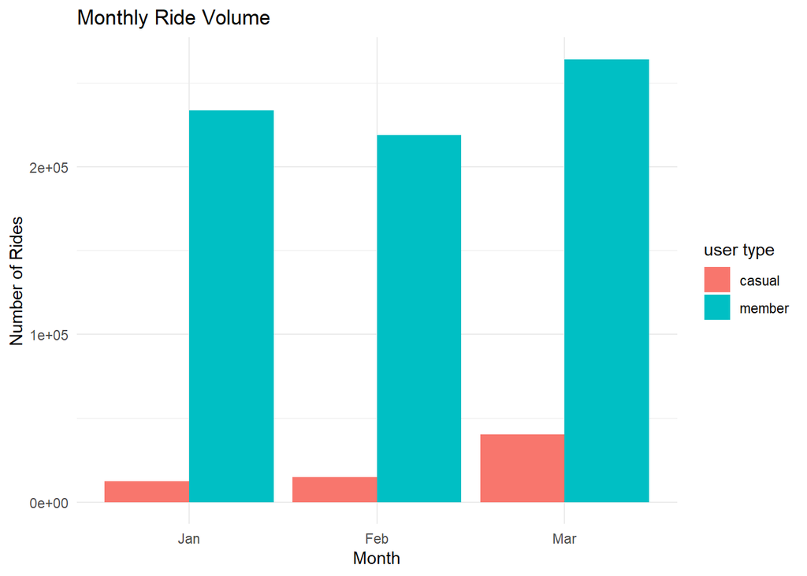

```r
all_trips_clean %>%
  group_by(usertype, month) %>%
  summarise(num_of_rides= n()) %>%
  ggplot(aes(x= month, y= num_of_rides, fill= usertype))+
  geom_col(position = "dodge") +
  labs(title = "Monthly Ride Volume",
       x = "Month",
       y = "Number of Rides",
       fill = "user type") +
  theme_minimal()
```

. Ride count by hour of the day.

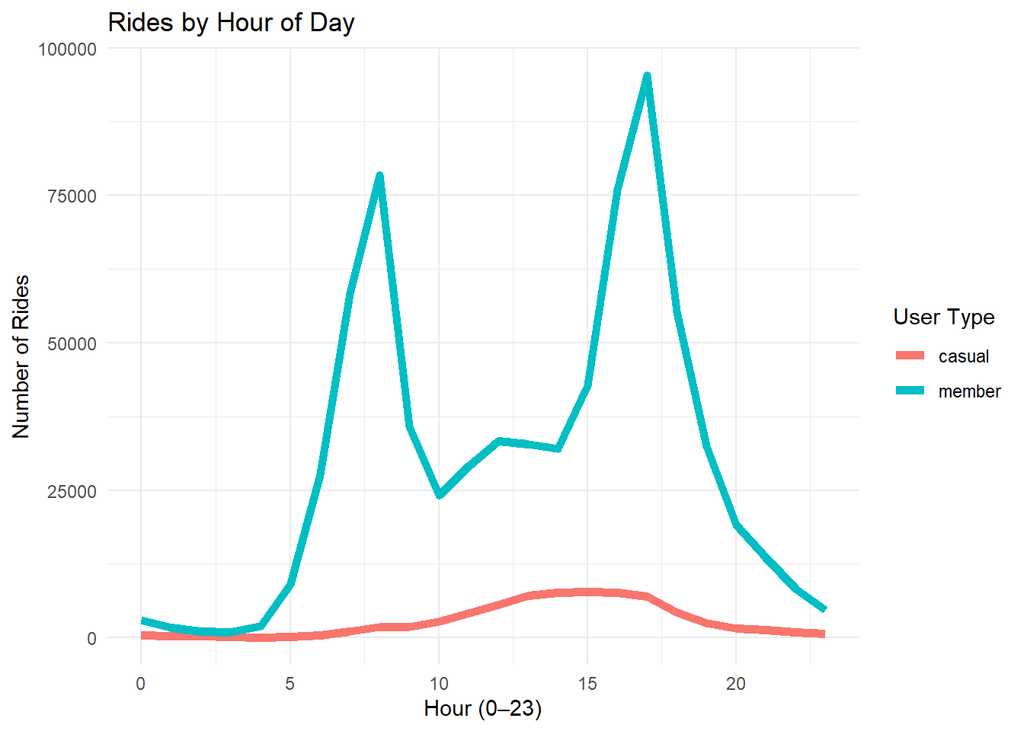

```r
all_trips_clean %>%
  group_by(usertype, hour) %>%
  summarise(num_rides = n()) %>%
  ggplot(aes(x = hour, y = num_rides, color = usertype)) +
  geom_line(size = 2 ) +
  labs(title = "Rides by Hour of Day",
       x = "Hour (0–23)",
       y = "Number of Rides",
       color = "User Type") +
  theme_minimal()
```

### Key Findings

. Members are most active on weekdays.

. 8 Am and 5 pm are the rush hours for members.

### 6. ACT PHASE

Recommendations:

1. Offer limited-time discounts or “try-a-membership” promos to convert frequent users into members.
2. Promote highlight benifits for the membership ex(lower cost per ride, faster checkouts or exclusive access for specific crowded stations).
3. Advertise at popular casual rider start stations, especially on weekends.